# Quiz-1 on 11-Feb-2019

**TIME: 80 min. 10:05am to 11:25am**

Please to the following tasks and upload the jupyter ipynb file (not html).

- The assignment portal will keep accepting submissions past deadline mentioned above
- Time of submission will be the timestamp on your submission
- Penalty of 5% for every 5 min of late submission.
- You may use any TEXT online resourse; for each question, the first cell of your answer for the Task should contain all the resourses you have accessed (URL)
- You are not allowed to post to and answer discussion forums, this is equivalent to having a discussion with another person during the quiz
- You are NOT allowed to access your previous class work or home work.
- All tasks carry equal weightage, so plan to spend equal amount of time.

# Task-1: Bounds for Pi

**A Regular polygon is a polygon having all sides of same size (equilateral) and all sides subtending same angle at the center of the polygon.**

- A circle can be approximated by INSCRIBING regular polygon (largest Regular polygon that lies completely inside the circle)
- A Circle can also approximated by CIRCUMSCRIBING regular polygon (smallest Regular polygon that completely covers all of the circle)

**Plot the bounds of $\pi$ vs $N$ where $N$ is the number of sides of regular polygon**

**Enter in the below cell, Resourses used in this Task**

```python
http://people.wku.edu/david.neal/117/Acad/8.%20Pi.pdf
```

[output not shown]

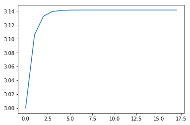

```python
import numpy as np
import matplotlib.pyplot as plt

def inscribed(steps):
    answer=[]
    intermediate=[]
    value=6
    intermediate.append(value)#starting with 6
    sin=1
    b=0
    answer.append(value/2)
    for i in range(steps-1):
       value=2*value
       intermediate.append(value)
       b=np.sqrt(2-np.sqrt(4-sin**2))
       sin=b
       answer.append(value*(sin/2))

    plt.plot(range(steps),answer)


inscribed(18)
```

# Task-2: Another map

In this task we will consider a peice wise linear map, $$f(x) = 2x \mod 1, \text{ where } n\in\mathcal{N}$$

1. Phase plot of the map (i.e. $x_{n-1}$ vs $x_n$)
2. Find the behaviour of the map. (HINT: Does this map have bifurcating steady-states etc. like logistic map)

**Enter the resourses used for this task in below cell**

```python
import numpy as np
import matplotlib.pyplot as plt

def func(x):
    return 2*x %1

def phaseplot(a,n):
    x=a
    plt.plot([0,1],[0,1])
    for i in range(n):
        y=func(x)
        plt.plot([x,x,y],[x,y,y])
        x=y
    return
```

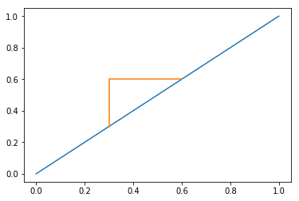

```python
phaseplot(0.3,1)
```

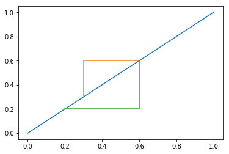

```python
phaseplot(0.3,2)
```

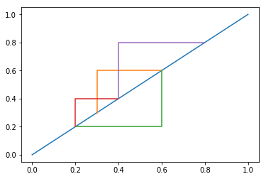

```python
phaseplot(0.3,4)
```

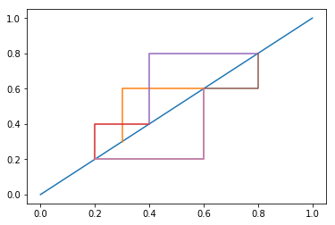

```python
phaseplot(0.3,6) #now the plot goes into an infinite loop as the value has reoccured so the same plot is regenerated at each further step
```

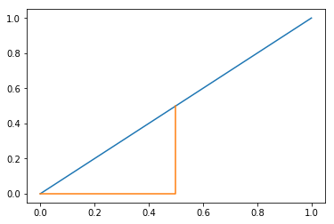

```python
phaseplot(0.5,10)#this plot deserves a special mention as in it the graph reaches a steady state value of 0 after the very first step and hence sticks to the value even after further steps
```

```python
import numpy as np
import matplotlib.pyplot as plt
def Task1(x):
    return 2*x %1

def Task2(xx):
    b=[0]*1000
    b[0]=xx
    #i will be storing the values of f(f(...(x))) in b
    for i in range(1,1000):
        b[i]=Task1(b[i-1])
    val=b[0]
    for i in range(1,1000):
        if(abs(b[i]-val)<0.00001):
            pos=i
            break
        elif(abs(b[i]-0)<0.00001):
            pos=i
            break
    print("The number of cycles is : ",pos)
    print("The steady states are as follows : ")
    for i in range(pos+1):
        print(b[i])
```

```python
Task2(0.6)
```

```
The number of cycles is :  4
The steady states are as follows :
0.6
0.19999999999999996
0.3999999999999999
0.7999999999999998
0.5999999999999996
```

```python
Task2(0.4)
```

```
The number of cycles is :  4
The steady states are as follows :
0.4
0.8
0.6000000000000001
0.20000000000000018
0.40000000000000036
```

```python
Task2(0.33) #the number of iterations before it could reach the steady state increased
```

```
The number of cycles is :  54
The steady states are as follows :
0.33
0.66
0.32000000000000006
0.6400000000000001
0.28000000000000025
0.5600000000000005
0.120000000000001
0.240000000000002
0.480000000000004
0.960000000000008
0.9200000000000159
0.8400000000000318
0.6800000000000637
0.36000000000012733
0.7200000000002547
0.4400000000005093
0.8800000000010186
0.7600000000020373
0.5200000000040745
0.04000000000814907
0.08000000001629815
0.1600000000325963
0.3200000000651926
0.6400000001303852
0.2800000002607703
0.5600000005215406
0.12000000104308128
0.24000000208616257
0.48000000417232513
0.9600000083446503
0.9200000166893005
0.8400000333786011
0.6800000667572021
0.3600001335144043
0.7200002670288086
0.4400005340576172
0.8800010681152344
0.7600021362304688
0.5200042724609375
0.040008544921875
0.08001708984375
0.1600341796875
0.320068359375
0.64013671875
0.2802734375
0.560546875
0.12109375
0.2421875
0.484375
0.96875
0.9375
0.875
0.75
0.5
0.0
```

# Analysis

```python
#so seeing the results we can conclude that yes the number of steady states vary but we cannot determine a pattern like we could in logistical maps as these are bifurcations that happen randomly between 0 and 1 based on the divisibility of twice the number with x
```

# Task-3: Symbolic manipulation

**Consider the expression $f(x) = a_2 x^2 + a_1 x + a_0$**

1. Compute symbolically the area under the curve from $a$ to $b$
2. Is it possible to compute the root symbolically i.e. solve symbolically for $f(x)=0$

   **Enter in the below cell the resourses used for this task:**

```python
import numpy as np
import scipy as sp
import matplotlib.pyplot as plt

def areacalculate(a2,a1,a0,a,b,N):
    hmax=(b-a)/N
    #h max is used to calculate h for the respective integral
    calc=0
    i=a
    while True:
        #infinite loop
        h=hmax/(1+abs(functionddx(a2,a1,i)))
        #this makes h small for large values of differential
        #this makes h variable and therefore accomodates for adaptive size grids
        if i==a :
            calc+=0.5*h*function(a2,a1,a0,i)
            #boundary values have a coefficient of 0.5 multiplied
        else:
            calc+=h*function(a2,a1,a0,i)
        i+=h
        if i>=b:
            break
    return calc
def function(a2,a1,a0,x):
    #calculating the value at certain x
    return a2*x*x+a1*x+a0
def functionddx(a2,a1,x):
    #this function returns the differential of the function at x
    return 2*x*a2 + a1
```

```python
areacalculate(0,1,0,0,4,10000) #value of y=x btw 0-4 is 8
```

```
8.000399999999246
```

```python
areacalculate(1,-4,0,0,4,10000) #value of y=x**2-4*x between 0 and 4 is -32/3
```

```
-10.666666670934232
```

```python
areacalculate(1,0,1,2,5,10000) #value of y=x**2 +1 between 2 and 5 is 42
```

```
41.99973867821494
```

```python
def roots(a2,a1,a0):
    a=(np.roots([a2,a1,a0]))
    print ("Roots are :")
    print ("Root 1 :")
    print(a[0])
    print ("Root 2 :")
    print(a[1])

#this program prints roots using the module roots in numpy
```

```python
roots(1,-4,0)
```

```
Roots are :
Root 1 :
4.0
Root 2 :
0.0
```

```python
https://www.w3resource.com/python-exercises/numpy/python-numpy-math-exercise-16.php
```